# wine_report

2022-06-16

```r
#loading required packages
library(tidyverse)
library(dplyr)
library(janitor)
library(skimr)
library(GGally)
library(gridExtra)
library(here)
library(DT)
```

## introduction

this report is a result of my exploration on [Red Wine Quality dataset](https://www.kaggle.com/datasets/uciml/red-wine-quality-cortez-et-al-2009), as a submission for the second assignment of Misk data science course.

to get back to the source repo [here](https://github.com/Misk-DSI/individual-assignment-2-Salma7577)

## Data

| Variable | Description |
| --- | --- |
| fixed_acidity | most acids involved with wine or fixed or nonvolatile (do not evaporate readily)(g/ml) |
| volatile_acidity | the amount of acetic acid in wine, which at too high of levels can lead to an unpleasant, vinegar taste (g/ml |
| citric_acid | found in small quantities, citric acid can add ‘freshness’ and flavor to wines(g/l) |
| residual_sugar | the amount of sugar remaining after fermentation stops, it’s rare to find wines with less than 1 gram/liter and wines with greater than 45 grams/liter are considered sweet(g/l) |
| chlorides | the amount of salt in the wine(g/l) |
| free_sulfur_dioxide | the free form of SO2 exists in equilibrium between molecular SO2 (as a dissolved gas) and bisulfite ion; it prevents microbial growth and the oxidation of wine(mg/l) |
| total_sulfur_dioxide | amount of free and bound forms of S02; in low concentrations, SO2 is mostly undetectable in wine, but at free SO2 concentrations over 50 ppm, SO2 becomes evident in the nose and taste of wine(mg/l) |
| density | the density of water is close to that of water depending on the percent alcohol and sugar content(g/mL) |
| pH | describes how acidic or basic a wine is on a scale from 0 (very acidic) to 14 (very basic); most wines are between 3-4 on the pH scale |
| sulphates | a wine additive which can contribute to sulfur dioxide gas (S02) levels, which acts as an antimicrobial and antioxidant(mg/l) |
| alcohol | the percent alcohol content of the wine(%abv) |
| quality | Quality of wine scale between 0 - 10 (target variable) |

```r
datatable(wine)
```

|  | fixed_acidity | volatile_acidity | citric_acid | residual_sugar | chlorides | free_sulfur_dioxide | total_sulfur_dioxide | density | pH | sulphates | alcohol | quality |
| --- | --- | --- | --- | --- | --- | --- | --- | --- | --- | --- | --- | --- |
| 1 | 7.4 | 0.7 | 0 | 1.9 | 0.076 | 11 | 34 | 0.9978 | 3.51 | 0.56 | 9.4 | 5 |
| 2 | 7.8 | 0.88 | 0 | 2.6 | 0.098 | 25 | 67 | 0.9968 | 3.2 | 0.68 | 9.8 | 5 |
| 3 | 7.8 | 0.76 | 0.04 | 2.3 | 0.092 | 15 | 54 | 0.997 | 3.26 | 0.65 | 9.8 | 5 |
| 4 | 11.2 | 0.28 | 0.56 | 1.9 | 0.075 | 17 | 60 | 0.998 | 3.16 | 0.58 | 9.8 | 6 |
| 5 | 7.4 | 0.7 | 0 | 1.9 | 0.076 | 11 | 34 | 0.9978 | 3.51 | 0.56 | 9.4 | 5 |
| 6 | 7.4 | 0.66 | 0 | 1.8 | 0.075 | 13 | 40 | 0.9978 | 3.51 | 0.56 | 9.4 | 5 |
| 7 | 7.9 | 0.6 | 0.06 | 1.6 | 0.069 | 15 | 59 | 0.9964 | 3.3 | 0.46 | 9.4 | 5 |
| 8 | 7.3 | 0.65 | 0 | 1.2 | 0.065 | 15 | 21 | 0.9946 | 3.39 | 0.47 | 10 | 7 |
| 9 | 7.8 | 0.58 | 0.02 | 2 | 0.073 | 9 | 18 | 0.9968 | 3.36 | 0.57 | 9.5 | 7 |
| 10 | 7.5 | 0.5 | 0.36 | 6.1 | 0.071 | 17 | 102 | 0.9978 | 3.35 | 0.8 | 10.5 | 5 |

[output cut: 1589 more lines]

## EDA

firstly, we will take a look on the structure of the dataset to know what we are dealing with.

```r
str(wine)
```

```
## tibble [1,599 × 12] (S3: tbl_df/tbl/data.frame)
##  $ fixed_acidity       : num [1:1599] 7.4 7.8 7.8 11.2 7.4 7.4 7.9 7.3 7.8 7.5 ...
##  $ volatile_acidity    : num [1:1599] 0.7 0.88 0.76 0.28 0.7 0.66 0.6 0.65 0.58 0.5 ...
##  $ citric_acid         : num [1:1599] 0 0 0.04 0.56 0 0 0.06 0 0.02 0.36 ...
##  $ residual_sugar      : num [1:1599] 1.9 2.6 2.3 1.9 1.9 1.8 1.6 1.2 2 6.1 ...
##  $ chlorides           : num [1:1599] 0.076 0.098 0.092 0.075 0.076 0.075 0.069 0.065 0.073 0.071 ...
##  $ free_sulfur_dioxide : num [1:1599] 11 25 15 17 11 13 15 15 9 17 ...
##  $ total_sulfur_dioxide: num [1:1599] 34 67 54 60 34 40 59 21 18 102 ...
##  $ density             : num [1:1599] 0.998 0.997 0.997 0.998 0.998 ...
##  $ pH                  : num [1:1599] 3.51 3.2 3.26 3.16 3.51 3.51 3.3 3.39 3.36 3.35 ...
##  $ sulphates           : num [1:1599] 0.56 0.68 0.65 0.58 0.56 0.56 0.46 0.47 0.57 0.8 ...
##  $ alcohol             : num [1:1599] 9.4 9.8 9.8 9.8 9.4 9.4 9.4 10 9.5 10.5 ...
##  $ quality             : Factor w/ 6 levels "3","4","5","6",..: 3 3 3 4 3 3 3 5 5 3 ...
```

we can see the name of the variables is slightly different(i.e. “janitor::clean_names()” has been used) and quality is now a factor(i.e “as.factor(wine$quality)” used) instead of a an integer interval between 0-10, those changes has been made to make this EDA more convenient.

### Wine Quality distribution

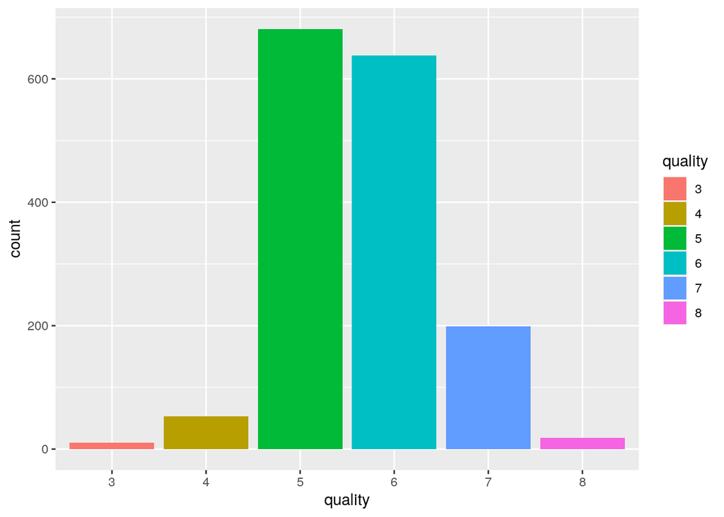

```r
wine %>%
  ggplot(aes(x=quality, fill=quality)) +
  geom_bar()
```

well this is interesting from the plot we notice that wine quality has a normal distribution most of the entities are between 5-6 with wines rated only inside the interval [3,8] instead of [0,10].

### Wine variables distribution

lets take a look at the other variables distribution

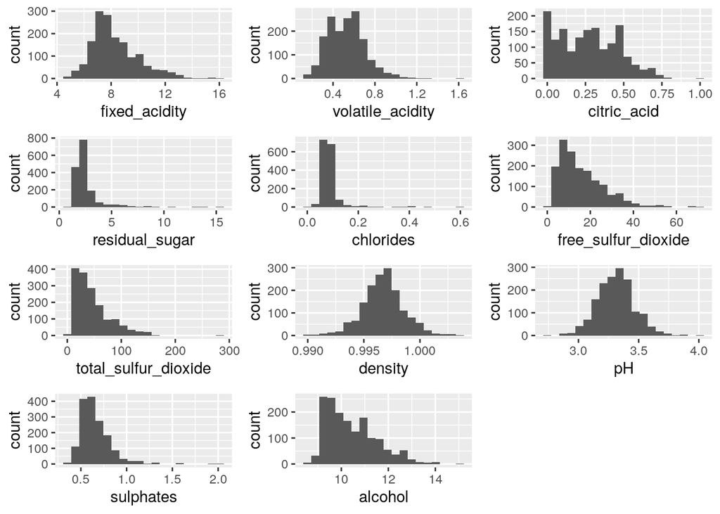

```r
g1 <- wine %>% ggplot(aes(x=fixed_acidity)) + geom_histogram(bins = 20)
g2 <- wine %>% ggplot(aes(x=volatile_acidity)) + geom_histogram(bins = 20)
g3 <- wine %>% ggplot(aes(x=citric_acid)) + geom_histogram(bins = 20)
g4 <- wine %>% ggplot(aes(x=residual_sugar)) + geom_histogram(bins = 20)
g5 <- wine %>% ggplot(aes(x=chlorides)) + geom_histogram(bins = 20)
g6 <- wine %>% ggplot(aes(x=free_sulfur_dioxide)) + geom_histogram(bins = 20)
g7 <- wine %>% ggplot(aes(x=total_sulfur_dioxide)) + geom_histogram(bins = 20)
g8 <- wine %>% ggplot(aes(x=density)) + geom_histogram(bins = 20)
g9 <- wine %>% ggplot(aes(x=pH)) + geom_histogram(bins = 20)
g10 <- wine %>% ggplot(aes(x=sulphates)) + geom_histogram(bins = 20)
g11 <- wine %>% ggplot(aes(x=alcohol)) + geom_histogram(bins = 20)

grid.arrange(g1,g2,g3,g4,g5,g6,g7,g8,g9,g10,g11)
```

from the plots above we can see that the distribution of the variables are either normally distributed or right-skewed.

Density and pH are normally distributed, which tells us that the red wines have a small difference in these two variables.

### quality variables relationship

#### quality & volatile_acidity

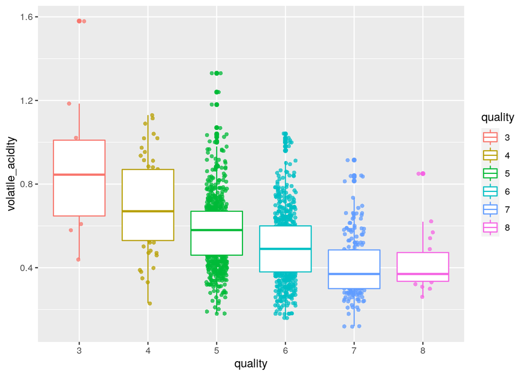

```r
 ggplot(wine,aes(x=quality, y= volatile_acidity, color = quality)) +
  geom_jitter(width = 0.15, shape = 16, alpha = 0.75) +
  geom_boxplot()
```

it seems volatile_acidity has a negative effect on quality “downward trend”.

#### quality & citric_acid

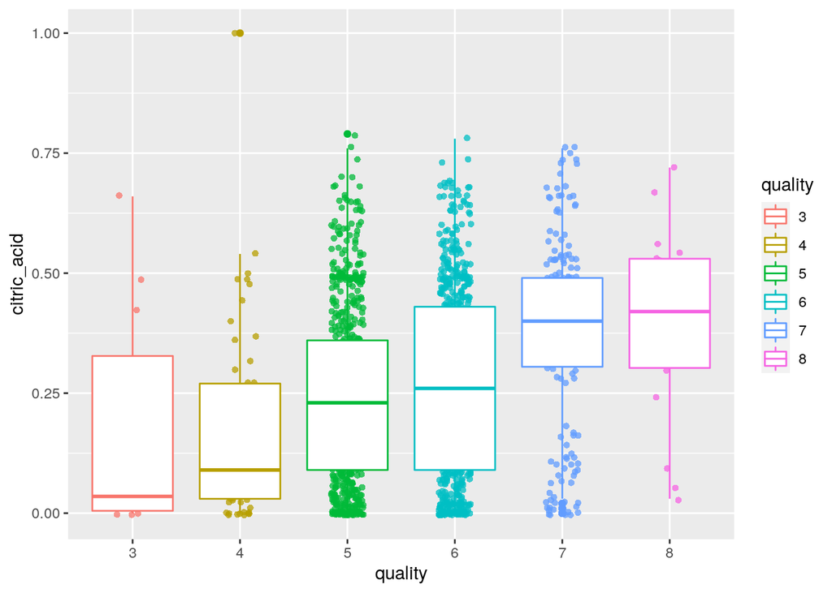

```r
ggplot(wine,aes(x=quality, y= citric_acid,color = quality)) +
  geom_jitter(width = 0.15, shape = 16, alpha = 0.75) +
  geom_boxplot()
```

it seems citric_acid has a positive effect on quality “upward trend”.

#### quality & density

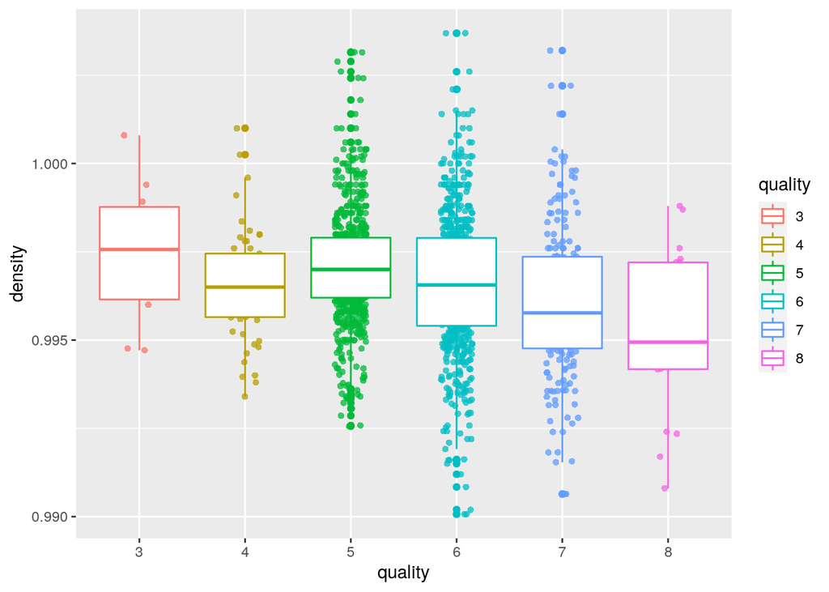

```r
ggplot(wine,aes(x=quality, y= density,color = quality)) +
  geom_jitter(width = 0.15, shape = 16, alpha = 0.75) +
  geom_boxplot()
```

it seems density has a negative effect on quality “downward trend”.

#### quality & sulphates

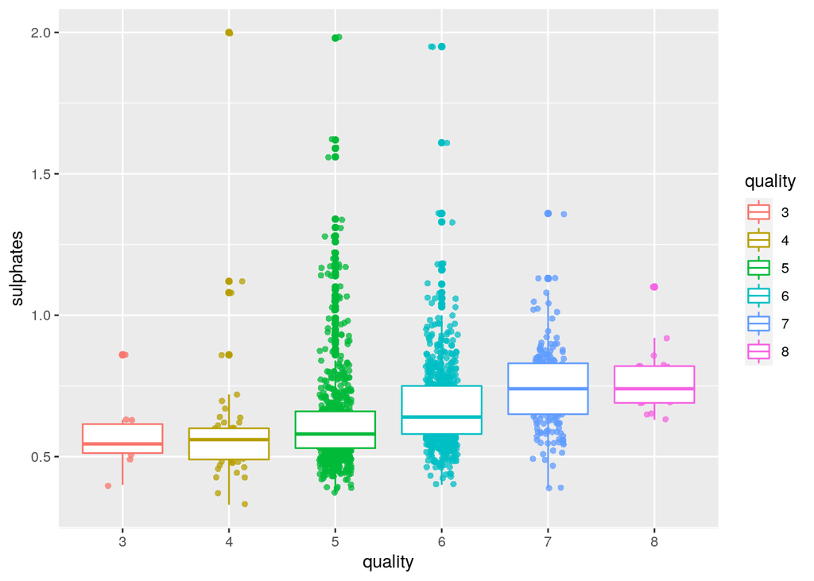

it seems sulphates has a positive effect on quality “upward trend”.

#### quality & alcohol

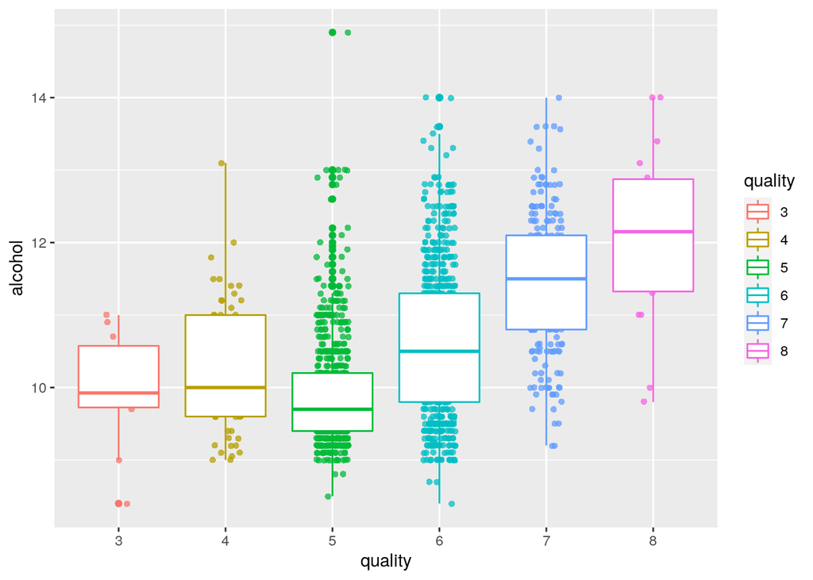

```r
 ggplot(wine,aes(x=quality, y= alcohol,color = quality)) +
  geom_jitter(width = 0.15, shape = 16, alpha = 0.75) +
  geom_boxplot()
```

it seems alcohol has a positive effect on quality “upward trend”.

#### other variables

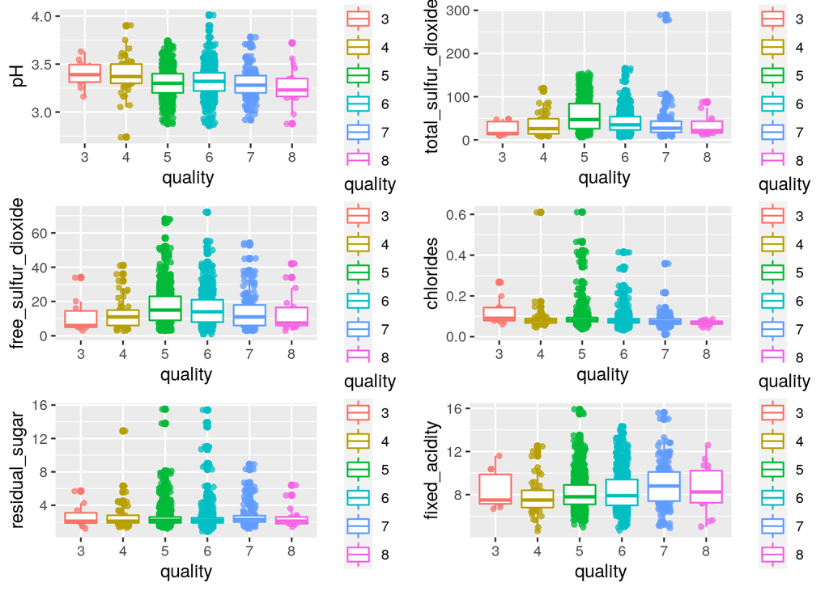

```r
rel1 <- ggplot(wine,aes(x=quality, y= pH,color = quality)) +
  geom_jitter(width = 0.15, shape = 16, alpha = 0.75) +
  geom_boxplot()

rel2 <- ggplot(wine,aes(x=quality, y= total_sulfur_dioxide,color = quality)) +
  geom_jitter(width = 0.15, shape = 16, alpha = 0.75) +
  geom_boxplot()

rel3 <- ggplot(wine,aes(x=quality, y= free_sulfur_dioxide, color = quality)) +
  geom_jitter(width = 0.15, shape = 16, alpha = 0.75) +
  geom_boxplot()

rel4 <- ggplot(wine,aes(x=quality, y= chlorides, color = quality)) +
   geom_jitter(width = 0.15, shape = 16, alpha = 0.75) +
  geom_boxplot()

rel5 <- ggplot(wine,aes(x=quality, y= residual_sugar, color = quality)) +
  geom_jitter(width = 0.15, shape = 16, alpha = 0.75) +
  geom_boxplot()

rel6 <- ggplot(wine,aes(x=quality, y= fixed_acidity, color = quality)) +
   geom_jitter(width = 0.15, shape = 16, alpha = 0.75) +
   geom_boxplot()


grid.arrange(rel1,rel2,rel3,rel4,rel5,rel6)
```

from the above plot we can see that these variables seems to have no effect on the quality of the red wine.

## Conclusion

from the EDA above we discovered a few interesting thing such as:

- quality ratings are only between 3 and 8 which indicates that there might be a systematic error or any kind of unbalance of those rating.
- quality ratings has a normal distribution along with some of the wines attributes such as density and pH.
- their is a positive relationship between the quality of the red wine and citric_acid,sulphates and alcohol more of those usually mean more quality.
- their is a negative relationship between the quality of the red wine and volatile_acidity,density.
- pH,total_sulfur_dioxide,free_sulfur_dioxide,chlorides,residual_sugar and fixed_acidity seems to have no effect on the quailty of the red wine.